# Excercises for Bernouli, Binomial and Poisson distribution

Marcin Szymkowiak and Maciej Beręsewicz

# Bernoulli / Binomial distribution

## Ex 1

During trening basketball player throws 10 times for 3 points. Probability of success in a single shot is 0.4. Let $X$ be random variable denoting number of accurate throw.

- Find the distribution of $X$.
- Create a plot for the distribution of $X$.
- Find probability that the player throws exactly 6 times
- Find probability that the player throws at most 3 times

### Solutions – R

```r
p <- 0.4
n <- 10
## pt 1
dbinom(x = 0:n, n, prob = p)  ## pdf
```

```
 [1] 0.0060466176 0.0403107840 0.1209323520 0.2149908480 0.2508226560 0.2006581248 0.1114767360 0.0424673280 0.0106168320
[10] 0.0015728640 0.0001048576
```

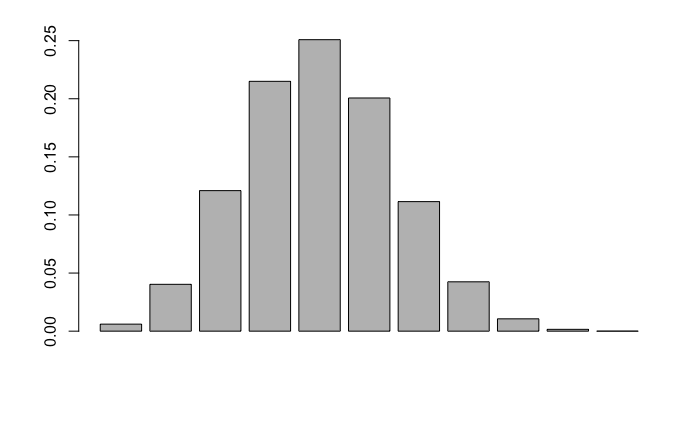

```r
## pt 2
barplot(dbinom(x = 0:n, n, prob = p))
```

```r
## pt 3
dbinom(x = 6, n, p)
```

```
[1] 0.1114767
```

```r
## pt 4
pbinom(3,n,p)
```

```
[1] 0.3822806
```

### Solutions – Python

```python
import numpy as np
import scipy.stats as stats
import matplotlib.pyplot as plot
n, p = 10, 0.4 ## n=10, p=0.4
# pt 1
a = stats.binom.pmf(k = np.arange(0,n+1), n=n, p=p)
print(a)
# pt 2
plot.bar(x = np.arange(0,n+1), height = a)
# plot.show() -- to see the plot
# pt 3
c = stats.binom.pmf(k = 6, n=n, p=p)
print(c)
# pt 4
d = stats.binom.cdf(k = 3, n=n, p=p)
print(d)
```

```
[6.04661760e-03 4.03107840e-02 1.20932352e-01 2.14990848e-01
 2.50822656e-01 2.00658125e-01 1.11476736e-01 4.24673280e-02
 1.06168320e-02 1.57286400e-03 1.04857600e-04]
0.11147673600000013
0.3822806016000001
```

### Solutions – Julia

```julia
using Distributions ## for distributions
n, p = 10, 0.4;
# pt  1
a = pdf.(Binomial(n, p), 0:n) ## we need to use pdf. instead of pdf because 0:n is vector
print(a)
# pt 2

# pt 3
c = pdf(Binomial(n, p), 6)
print(c)
# pt 4
c = cdf(Binomial(n, p), 3)
print(c)
```

```
[0.00604662, 0.0403108, 0.120932, 0.214991, 0.250823, 0.200658, 0.111477, 0.0424673, 0.0106168, 0.00157286, 0.000104858]0.111476736000000030.3822806015999999
```

## Ex 2

Shooter fires 5 times at the target. Probability of hit in a single shot equals 0.8. Let $X$ be the random variable denotes numer of hits (successes), then

- Find the distribution of random variable $X$.
- Create a plot of the distribution of $X$.
- Find the probability that archerer will hit exactly 4 times
- Find the probability that archerer will hit exactly at most 3 times
- Find the probability that archerer will hit exactly at least 2 times

## Ex 3

Some family plans to have 3 children. Assuming that there is no correlation between birth of girl and boy, probability of having a girl equals 0.483. Find the distribution of random variable defined as number of boys in 3 children in this family. Calculate expected value and variance.

## Ex 4

Assume that, random variable $X$ follows binomial distribution with probability of success $p=0.6$. Create a plot assuming that number of trials $n$ equals to $5,10,15,20$.

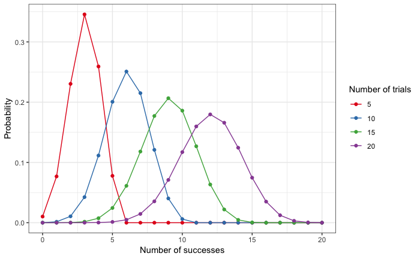

```r
library(ggplot2)
library(tidyverse)
expand.grid(0:20, c(5,10,15,20)) %>%
  #filter(Var1 <= Var2) %>%
  mutate(pdf = dbinom(x = Var1, size = Var2, p = 0.6),
         Var2 = factor(Var2)) %>%
  ggplot(data = .,
         aes(x = Var1,
             y = pdf,
             color = Var2,
             group = Var2)) +
  geom_line() +
  geom_point() +
  #geom_col() +
  theme_bw() +
  labs(x = "Number of successes",
       y = "Probability") +
  scale_color_brewer(name  = "Number of trials",
                     type = "qual",
                     palette = "Set1")
```

```r
NA
```

## Ex 5

There are five white balls and two black balls. We draw with returning three times a ball. Give the probability distribution the number of drawn white balls and calculate the parameters of this distribution.

## Ex 6

In the window manufacturing company, the employee supports 5 machines that produce a certain element. The probability that the machine will not require repair during the day is 0.9. Machines work independently of each other.

- Calculate the probability distribution of the number of machines that will require repairs during their working day.
- Make a graph of the probability distribution of this variable.
- Calculate the probability that exactly 2 machines will require repairs during the day.
- Calculate the probability that at most 2 machines will require repair during the day.
- Calculate the probability that less than 2 machines will require repairs during the day.

## Ex 7

In a large company, 5 people work in the accounting department. The probability of failure to work due to the disease of each of them is 0.1. Calculate the probability that:

- all people will come to work.
- three people will not come to work.
- more than two people will not come to work.

## Ex 8

In ~a lot of 100 bulbs 10 are defective. The quality controller gets in an independent way $n = 8$ light bulbs.

- Find the distribution of the random variable $X$ taking the value equal to the number of broken defective bulbs drawn.
- Calculate $P(2 <X \ leq5)$.
- Calculate $P(X <4)$.
- Make a graph of the probability distribution of this variable.

## Ex 9

It is known that for a certain random variable $X$

$$P\left(X=k\right)={6 \choose k}\cdot p^{k}\cdot \left(1-p\right)^{6-k},\quad k=0,1,\ldots,6,\quad p=0.2.$$

Present the distribution of this variable graphically, calculate $P\left(X \geq 3\ right)$ and $P\left(X = 2 \right)$. Calculate the expected value, variance and standard deviation of the random variable $X$.

## Ex 10

In a certain insurance company, 5% of all reported damages are car accidents. What is the probability that among the reported 15 damages, the number of car accidents will be greater than 3.

# Poisson distribution

## Ex 1

A car salesman sales on average 5 cars. What is the probability that this dealer will sale at most 2 cars?

### Solutions – R

```r
lambda = 5
ppois(q = 2, lambda = 5)
```

```
[1] 0.124652
```

### Solutions – Python

```python
import scipy.stats as stats
lam = 5
res = stats.poisson.cdf(2, lam)
print(res)
```

```
0.12465201948308108
```

### Solutions – Julia

```julia
using Distributions
lambda = 5
a = cdf(Poisson(lambda), 2)
print(a)
```

```
0.12465201948308116
```

## Ex 2

A young mathematician writing his articles in the LaTeX program stated that he commits an average of 4 typos per page. We randomly select one of the many pages written by this mathematician. What is the probability that we will find at most 3 errors on it.

## Ex 3

The random variable $X$ has a Poisson distribution with ~ expected value of 3. Determine $P\left(X\leq 6 \right)$ and $P\left(X \geq 3 \right)$.

## Ex 4

For a certain random variable $X$ with Poisson distribution, there is a condition $P\left(X = 0 \right)= 0.2$. Find the distribution parameters of this variable.

## Ex 5

The random variable $X$ has a distribution specified by the following function:

$$P\left(X=k\right)=\frac{e^{-4}\cdot 4^{k}}{k!}, \quad k=0,1,\ldots$$

Determine the expected value and the standard deviation of the defined random variable and determine the probability that the random variable:

- will take the value equal to 1;
- will take no more than 3;
- will take a value above 5.

## Ex 6

The number of car accidents during the day in a certain city has a Poisson distribution with an expected value of $\lambda=2$. Find the probability that no more than 4 car accidents will take place during the day in the city.

## Ex 7

Random variable $X$ follows Poisson distribution with $\lambda=4$. Calculate:

- $P\left(X<3\right)$.
- $P\left(X>5\right)$.
- $P\left(X=2\right)$.

## Ex 8

The composition of a complicated apparatus includes 150 elements of a specific type. The probability of damage during the year of each of these elements is equal to 0.004 and does not depend on the condition of other elements. Calculate the probability of damage during the year not less than two elements.

## Ex 9

Suppose that a random variable $X$ has a Poisson distribution with ~ parameter $\lambda$. Make a graph of the probability distribution of the random variable $X$ in depending on the value of the parameter $\lambda$. Choose $\lambda = 2,5,8,10$.